# Topic B: The RREAAAPP Data Analysis Workflow

Smart Data Analysis in Health and Medicine — R, the RREAAAPP Workflow and AI Assistants

[Kamarul Imran Musa, MD PhD](https://myanalytics.com.my/)

drki.musa@gmail.com

Professor of Medical Epidemiology and Statistics, School of Medical Sciences, Universiti Sains Malaysia

7 November 2026

## Why a workflow?

**Without a workflow**

- Open the data and “see what happens”
- Forget which steps you did
- Results nobody can check or repeat

**With RREAAAPP**

- A clear reason first
- The same eight steps every time
- Every step written in code — checkable and repeatable

**Note**

A workflow is a **checklist for your thinking**, not just for your code.

## Meet Positron — your R home from now on

[figure not shown]

1. **File → Open Folder** (your project) · 2. click a script in the **Explorer** (left) · 3. put the cursor on a line, press **Ctrl + Enter** → R runs it in the **Console**; data appear in **Variables**, graphs in **Plots**. *No Positron? Use Posit Cloud — same code.*

## RREAAAPP at a glance

**R** — **Reason**: why are you analysing?

**R** — Read the data

**E** — Explore the data

**A** — Assume: make and check assumptions

**A** — Apply models and methods

**A** — Assess results and models

**P** — Present results and interpretations

**P** — Publish results, data and code

# Reason first

Know why you analyse — before you open R

## Reason: know why you are analysing

- **Research question** — what exactly do you want to know?
- **Study population** — who is it about? Who should be left out?
- **Outcome** — the main variable you want to explain
- **Explanatory variables** — what might be related to the outcome
- **Data** — which dataset, and is it fit for this question?

**Important**

If you cannot write your reason in **one sentence**, do not open R yet.

## Reason, applied to our data

Among adults **without known diabetes**, is a larger **waist circumference** associated with a higher **fasting blood sugar**, after taking **age and sex** into account?

| **Population** | Adults without a history of diabetes (`hx_dm2` = “no”) — treatment changes blood sugar |
| --- | --- |
| **Outcome** | `fasting_blood_sugar` (mmol/L) |
| **Explanatory** | `waist_cm` (main), `age`, `malefemale` (sex) |
| **Data** | `datasets/mssm_fbs_workshop.xlsx` (workshop version) |

# The steps in R

Read · Explore · Assume · Apply · Assess · Present · Publish

## Read

```r
fbs <- read_excel(here("datasets",
  "mssm_fbs_workshop.xlsx")) |>
  clean_names() |>           # tidy names
  filter(hx_dm2 == "no") |>  # Reason
  select(fasting_blood_sugar, waist_cm,
         age, malefemale)

dim(fbs)                    # rows, columns
```

```
[1] 3713    4
```

- `clean_names()` turns `hip circum (cm)` into `hip_circum_cm`
- The **Reason** decides `filter()` and `select()`

## Explore: look at the outcome

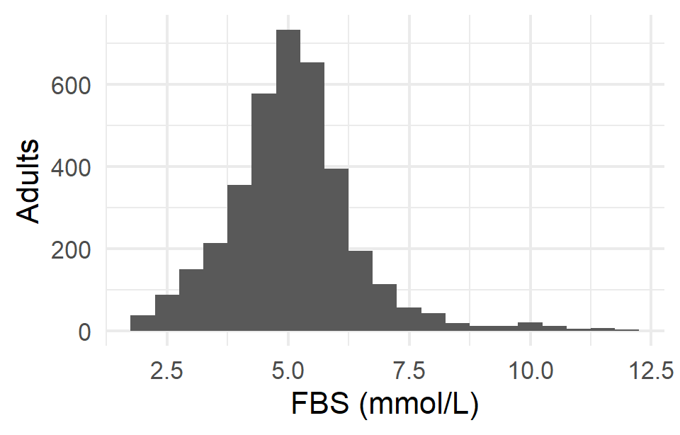

```r
ggplot(fbs,
  aes(fasting_blood_sugar)) +
  geom_histogram(
    binwidth = 0.5) +
  labs(x = "FBS (mmol/L)",
       y = "Adults")
```

```r
fbs |>
  select(fasting_blood_sugar) |>
  tbl_summary(
    type = everything() ~
      "continuous2",
    statistic = everything() ~ c(
      "{median} ({p25}, {p75})",
      "{min}, {max}"))
```

| **Characteristic** | **N = 3,713** |
| --- | --- |
| fasting_blood_sugar |  |
| Median (Q1, Q3) | 5.03 (4.34, 5.73) |
| Min, Max | 2.00, 11.91 |

## Explore: check data quality

```r
fbs |>
  summarise(
    lowest  = min(fasting_blood_sugar),
    highest = max(fasting_blood_sugar),
    below_3 = sum(fasting_blood_sugar < 3),
    missing = sum(is.na(fasting_blood_sugar))
  )
```

```
# A tibble: 1 × 4
  lowest highest below_3 missing
   <dbl>   <dbl>   <int>   <int>
1      2    11.9     182       0
```

- Before the workshop, the data owner **removed 214 people** with FBS below 2 or above 12 mmol/L as implausible — and **recorded why** (`datasets/README.md`)
- Still **182** values below 3 mmol/L — unusual in fasting adults: ask the data owner
- **Never delete quietly** — every exclusion is a decision you write down and report

## Assume

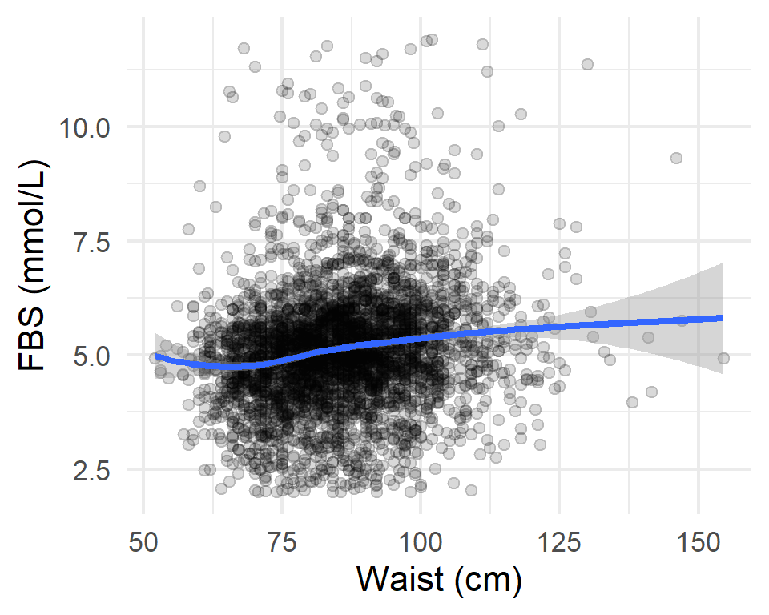

```r
ggplot(fbs, aes(waist_cm,
  fasting_blood_sugar)) +
  geom_point(alpha = .15) +
  geom_smooth(
    method = "loess") +
  labs(x = "Waist (cm)",
       y = "FBS (mmol/L)")
```

Linear regression **assumes**: (1) a roughly **straight-line** relationship — this curve checks it · (2) **independent** people (no repeated or family members) · (3) prediction errors roughly **normal** with **similar spread** — checked after the model (Assess)

## Apply

```r
model <- lm(fasting_blood_sugar ~ waist_cm + age +
              malefemale, data = fbs)

tidy(model, conf.int = TRUE) |>
  select(term, estimate, conf.low, conf.high)
```

```
# A tibble: 4 × 4
  term           estimate conf.low conf.high
  <chr>             <dbl>    <dbl>     <dbl>
1 (Intercept)      2.97     2.67      3.27
2 waist_cm         0.0146   0.0113    0.0180
3 age              0.0193   0.0163    0.0222
4 malefemalemale  -0.0679  -0.157     0.0217
```

## Reading the output in plain words

| Term | Plain words | Our result (waist) |
| --- | --- | --- |
| **Linear regression** (`lm`) | Fits a straight line through the dots | FBS rises with waist |
| **Estimate** | Change in the outcome for 1 unit more | +0.015 mmol/L per 1 cm |
| **95% CI** | Range of plausible values for the true effect | 0.011 to 0.018 — does not include 0 |
| **“Holding age and sex constant”** | Comparing people of the same age and sex | — |
| **R²** | Share of the differences in FBS the model explains | 0.069 ≈ 7% |
| **“Associated with”** | Go together — **not** “causes” | — |

## Assess

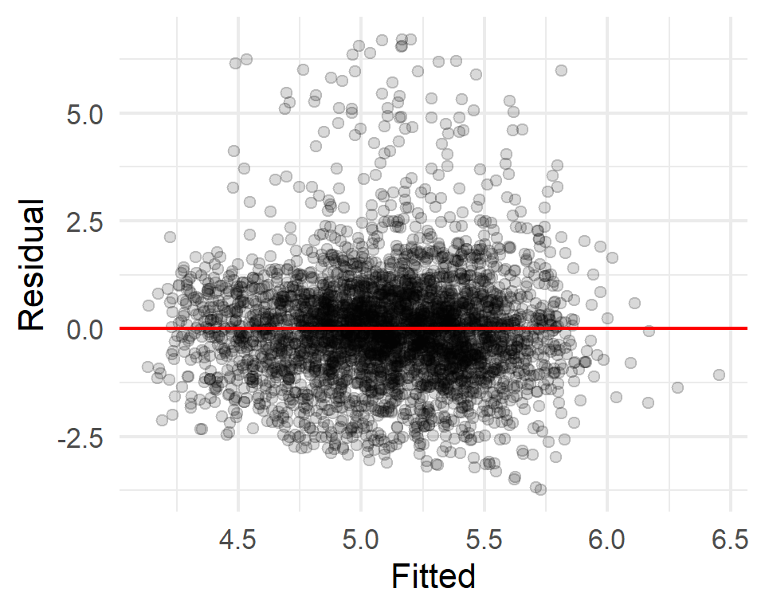

```r
augment(model) |>
  ggplot(aes(.fitted,
             .resid)) +
  geom_point(alpha = .15) +
  geom_hline(
    yintercept = 0,
    colour = "red") +
  labs(x = "Fitted",
       y = "Residual")
```

**Fitted** = the value the model predicts · **Residual** = observed − predicted. Good: a shapeless band around 0. Here: more points far above than below → treat the CI as **approximate**

## Present

```r
tbl_regression(
  model,
  label = list(waist_cm ~ "Waist (cm)",
               age ~ "Age (years)",
               malefemale ~ "Sex"),
  estimate_fun = label_style_number(digits = 3)
)
```

| **Characteristic** | **Beta** | **95% CI** | **p-value** |
| --- | --- | --- | --- |
| Waist (cm) | 0.015 | 0.011, 0.018 | <0.001 |
| Age (years) | 0.019 | 0.016, 0.022 | <0.001 |
| Sex |  |  |  |
| female | — | — |  |
| male | -0.068 | -0.157, 0.022 | 0.14 |

Abbreviation: CI = Confidence Interval

**Interpretation:** among people of the same age and sex, each extra 1 cm of waist was associated with **0.015 mmol/L** higher fasting blood sugar (95% CI 0.011 to 0.018). Small effect; the model explains about 7% of the variation.

## Publish

- Put the code, table and interpretation in a **Quarto report** (Topic A)
- Share the **code** so others can check it
- Share **data** only if ethics approval and the data owner allow it

**Warning**

Reports are public: never include data that could identify anyone (even age + sex + village).

## Hands-on (25 min) — in Positron

1. **Reason:** write your question, population, outcome and variables as comments

2. In **Positron**, open the `02_rreaaapp_project` folder, then `02_rreaaapp_starter.R`

3. Fill each `___` from your Reason; run Read and Explore line by line (**Ctrl + Enter**); note anything odd

4. Run Apply, Assess and Present; write **one sentence** of interpretation

**Stretch:** change the explanatory variable (e.g. `age` only) and compare

No Positron on your laptop? Use **Posit Cloud** — the code is the same.